# BFFMod: physiological models of Benthic Filter Feeder growth and populations

## The *BFFMod* package models dynamics of mussel growth & populations.

For now the package contains the following functions:

```r
ls("package:BFFMod")
##>  [1] "get_INI_coh"          "get_INI_indiv"        "make_ff"              "matplot.mussel"
##>  [5] "mussel_get_auxiliary" "mussel_get_debforcs"  "mussel_get_debparms"  "mussel_get_debstates"
##>  [9] "mussel_get_debvars"   "mussel_pop_struct"    "mussel_run_debcohort" "mussel_run_debind"
```

## Functions mussel_run_debind and mussel_run_debcohort

Function *mussel_run_debind* describes the dynamics of an average mussel individual, in terms of its physiological composition, based on the dynamic energy budget formulation.

```r
args(mussel_run_debind)
##> function (parms = list(), times = 0:365, yini = NULL, f_Phyto = 10,
##>     f_Temp = 20, f_Detritus = 10, f_Sim = 1, f_O2 = 360, f_tau = 0.01)
##> NULL
```

Function *mussel_run_debcohort* describes the dynamics of a mussel bed, or a shellfish population. Population dynamics, in terms of *Birth* and *Death* are derived form the average individual physiology of several cohorts. The default maximum number of cohorts is 12, spawning of larva can be once or twice a year.

```r
args(mussel_run_debcohort)
##> function (parms = list(), times = 0:365, yini = NULL, f_Phyto = 10,
##>     f_Temp = 20, f_Detritus = 10, f_Sim = 1, f_O2 = 360, f_tau = 0.01,
##>     max_cohort = 12, dynamic_environment = TRUE)
##> NULL
```

### Functions to obtain model default settings

The default parameters are suitable for modeling *Mytilus galloprovincialis* in the Black Sea

```r
args(mussel_get_debparms)
##> function (out, as.vector = FALSE, which = NULL)
##> NULL
```

```r
args(mussel_get_debvars)
##> function (out, as.vector = FALSE, which = NULL)
##> NULL
```

```r
args(mussel_get_debstates)
##> function (out, as.vector = FALSE, which = NULL)
##> NULL
```

## Application : DEB model for individual Growth

The individual growth model tracks the states of the individual The model follows Dynamic Energy Budget theory (DEB), According to DEB theory, an indiviudal can be expressed in 3 pools: **Structure**, **Reserve** & **Reproduction**. Here, the pools are expressed in their **Carbon biomass** whereas in most DEB models, they are expressed in energy (Reserve & Reproduction) or Volume (Structure). By simply calling the model and plotting the output, these DEB variables, and their cange over time, are shown. Since the model output also contains most physiological rates, we can request specific outputs with the plot function

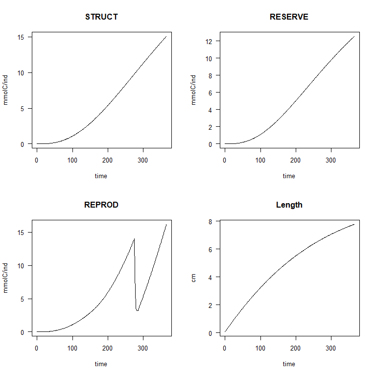

```r
mod1 <- mussel_run_debind()
plot(mod1, which = c("STRUCT","RESERVE","REPROD","Length"))
```

As we saw in the *args(mussel_run_debind)* command, this model run has a constant temperature (20dgC) and a high food cocentration (10 mmolC/m3 phytoplankton & 10 mmolC/m3 Detritus) In the result, we see a steady increase in structure & reserve buffer, the reproduction buffer is reduced at a certain point in time: this is a spawning event. We can get a better look at the spawning by dividing gonads and gametes (the 2 componenents of the reproduction buffer)

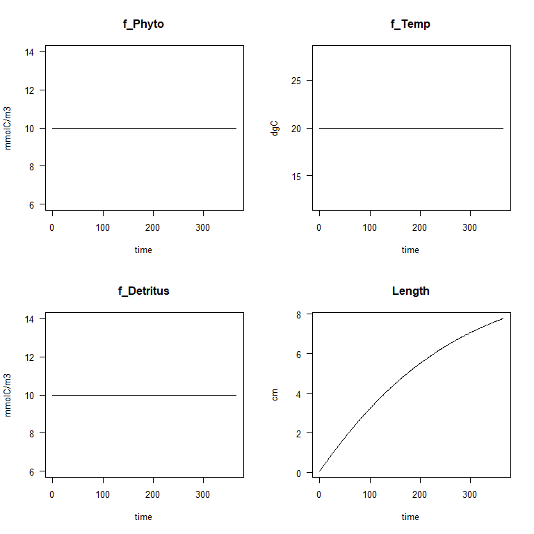

```r
plot(mod1, which = c("f_Phyto","f_Temp","f_Detritus","Length"))
```

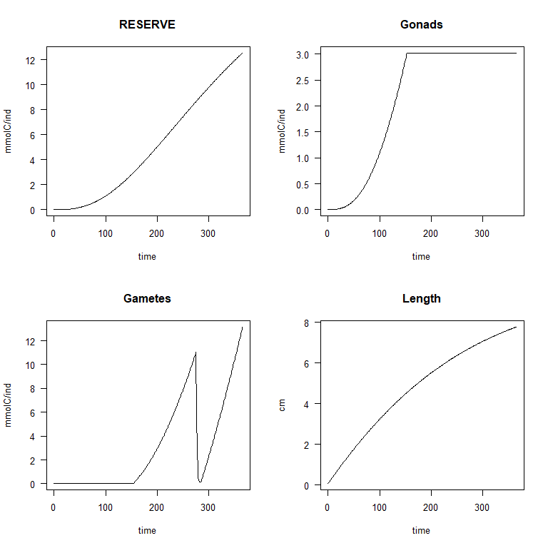

```r
plot(mod1, which = c("RESERVE","Gonads","Gametes","Length"))
```

Here we see that the Gonads first grow towards a threshold (we call maturity) and afterwards the gametes are produced and released during a spawning event.

## Manipulating environmental conditions

We can experiment with the model by trying to change the evironment as an example we can construct 4 model runs which differ in temperature and food conditions we can call the models HtHf (High temperature High food), HtLf, LtHf & LtLf. Additionally, the model run is now increased to 3 years of growth.

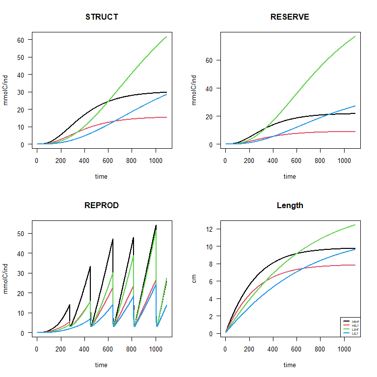

```r
HtHf <- mussel_run_debind(times = 0:(3*365), f_Phyto = 10, f_Temp = 20)
HtLf <- mussel_run_debind(times = 0:(3*365), f_Phyto = 5, f_Temp = 20)
LtHf <- mussel_run_debind(times = 0:(3*365), f_Phyto = 10, f_Temp = 5)
LtLf <- mussel_run_debind(times = 0:(3*365), f_Phyto = 5, f_Temp = 5)
plot(HtHf,HtLf,LtHf,LtLf,
     which = c("STRUCT","RESERVE","REPROD","Length"),
     lwd = 2)
legend("bottomright", col = c(1:4), legend = c("HtHf", "HtLf","LtHf","LtLf"), lwd = 2, cex=0.5)
```

According to the model, food is the most dominant factor in growth here, with the high food condition reaching double the size after 3 years. Additionally, high temperature causes a slightly faster growth rate, but a lower eventual size. this is because high temperature increases both rate of feeding, but also reparation costs. Especially reproductive success seems high under the high temperature environment, while low temperature allows for slower, but sustained growth.

## cumulative sum of reproductive output

To show the difference between length trajectory and fecundity we can calculate the cumulative sum of spawn_rate, which is the reproductive output in mmolC/day. we can transform the model output into an *R* data.frame for easy manipulationl.

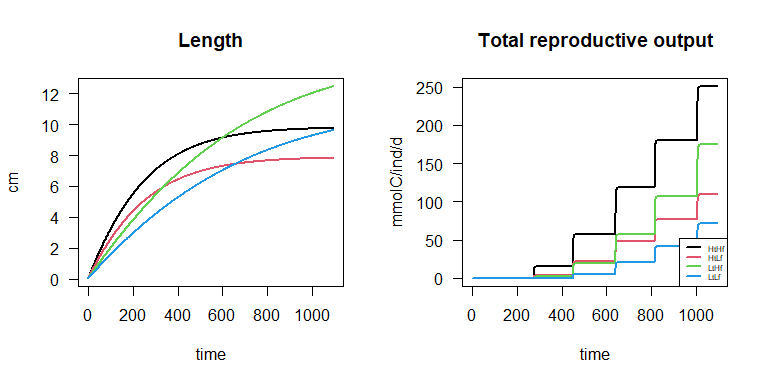

```r
HtHf[,"Spawn_rate"] <- cumsum(HtHf[,"Spawn_rate"])
HtLf[,"Spawn_rate"] <- cumsum(HtLf[,"Spawn_rate"])
LtHf[,"Spawn_rate"] <- cumsum(LtHf[,"Spawn_rate"])
LtLf[,"Spawn_rate"] <- cumsum(LtLf[,"Spawn_rate"])

plot(HtHf,HtLf,LtHf,LtLf, main = c("Length", "Total reproductive output"),
     which = c("Length","Spawn_rate"),
     lwd = 2)
legend("bottomright", col = c(1:4), legend = c("HtHf", "HtLf","LtHf","LtLf"), lwd = 2, cex=0.5)
```

Here, we can see that the biggest eventual length does not nessecarily correspond with the highest fecundity or reproductive success!

## Dynamic Environments.

The model is fully dynamic, the model can continually calculate growth even in a dynamic environment. Dynamic environments bring seasonality and realism into the growth trajectories. In *R* sine functions are a quick way to simulate fluctuating forcings.  
function(t) {max(0,(*AMPLITUDE* * sin((2*pi*(t-*STARTING OF SINE*)/365)) + *AVERAGE*)) + rnorm(length(t), *MEAN OF RANDOM ERROR*,*SD OF RANDOM ERROR*)}

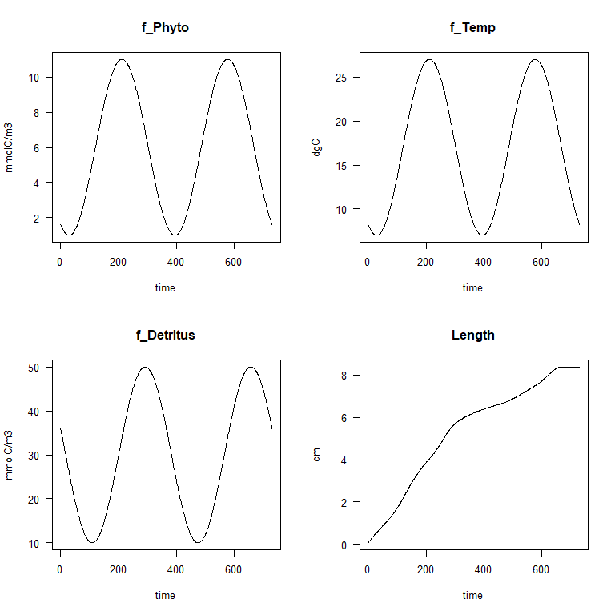

```r
f_dynaTEMP = function(t) {(10 * sin((2*pi*(t-120)/365)) + 17)}
f_dynaPHYTO = function(t) {(5 * sin((2*pi*(t-120)/365)) + 6)}
f_dynaDT = function(t) {(20 * sin((2*pi*(t-200)/365)) + 30)}
DYNAmod <- mussel_run_debind(times = 0:(2*365),
                             f_Phyto = f_dynaPHYTO,
                             f_Temp = f_dynaTEMP,
                             f_Detritus =f_dynaDT)
plot(DYNAmod, which = c("f_Phyto","f_Temp","f_Detritus","Length"))
```

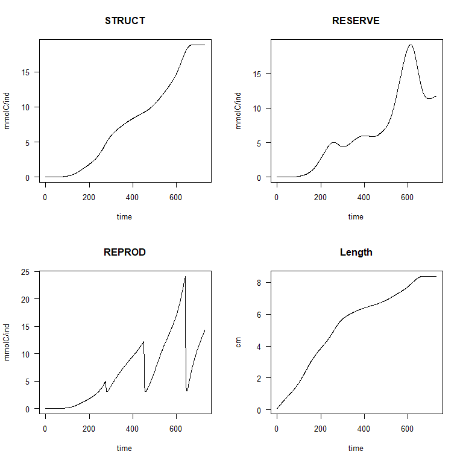

```r
plot(DYNAmod, which = c("STRUCT","RESERVE","REPROD","Length"))
```

In the dynamic example we can see rapid growth at some points of the year, and a stagnation at other points, due to swings in food concentration and temperature.

## Adittional Features on top of “standard DEB”

The default version of DEB models use only Food concentration and Temperature as environemtnal inputs. Here, we developed a model that includes the Saraiva Shellfish DEB feeding module (Saraiva et al., 2011), which allows us to include a secondary (less efficient) food type **Detritus** and inhibiting suspended inorganic matter **SIM**. Additionally, because the model is applied to the Black Sea, **Oxygen** concentration is also an input. As an example, we can run the model with a dynamic environment, and four different combinations of high/low Oxygen and SIM.

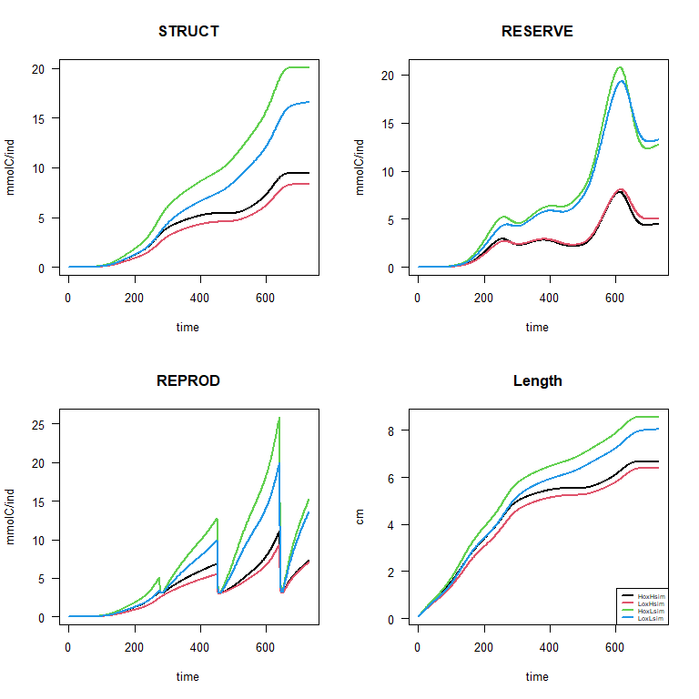

```r
DYNAmod_HoxHsim <- mussel_run_debind(times = 0:(2*365),
                             f_Phyto = f_dynaPHYTO,
                             f_Temp = f_dynaTEMP,
                             f_Detritus = f_dynaDT,
                             f_O2 = 400, f_Sim = 10)
DYNAmod_LoxHsim <- mussel_run_debind(times = 0:(2*365),
                             f_Phyto = f_dynaPHYTO,
                             f_Temp = f_dynaTEMP,
                             f_Detritus = f_dynaDT,
                             f_O2 = 80, f_Sim = 10)
DYNAmod_HoxLsim <- mussel_run_debind(times = 0:(2*365),
                             f_Phyto = f_dynaPHYTO,
                             f_Temp = f_dynaTEMP,
                             f_Detritus =f_dynaDT,
                             f_O2 = 400, f_Sim = 0.5)
DYNAmod_LoxLsim <- mussel_run_debind(times = 0:(2*365),
                             f_Phyto = f_dynaPHYTO,
                             f_Temp = f_dynaTEMP,
                             f_Detritus =f_dynaDT,
                             f_O2 = 80, f_Sim = 0.5)

plot(DYNAmod_HoxHsim,DYNAmod_LoxHsim,DYNAmod_HoxLsim,DYNAmod_LoxLsim,
     which = c("STRUCT","RESERVE","REPROD","Length"),
     lwd = 2)
legend("bottomright", col = c(1:4), legend = c("HoxHsim", "LoxHsim","HoxLsim","LoxLsim"),
       lwd = 2, cex = 0.5)
```

##### Experimenting with different levels of Oxygen, SIM and other environmental factors will yield different individual growth trajectories.

In a similar way, we can also track multiple physiological rates, such as Clearanc rate, assimilation of carbon and respiration

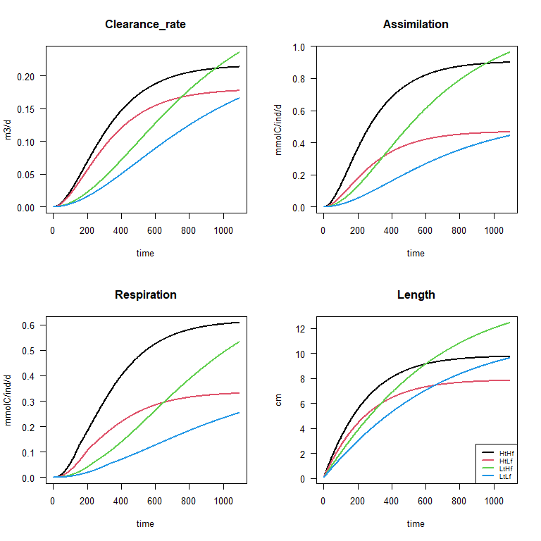

```r
plot(HtHf,HtLf,LtHf,LtLf,
     which = c("Clearance_rate","Assimilation","Respiration","Length"),
     lwd = 2)
legend("bottomright", col = c(1:4), legend = c("HtHf", "HtLf","LtHf","LtLf"), lwd = 2, cex=0.7)
```

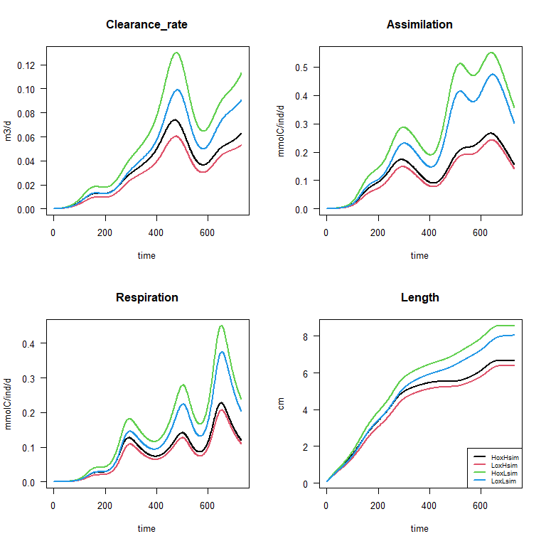

```r
plot(DYNAmod_HoxHsim,DYNAmod_LoxHsim,DYNAmod_HoxLsim,DYNAmod_LoxLsim,
     which = c("Clearance_rate","Assimilation","Respiration","Length"),
     lwd = 2)
legend("bottomright", col = c(1:4), legend = c("HoxHsim", "LoxHsim","HoxLsim","LoxLsim"),
       lwd = 2, cex = 0.7)
```

# Application : Population dynamics of *Mytilus galloprovincialis*

Population dynamics can be modeled with the function *mussel_run_debcohort()*. The default population is expressed in 12 cohorts which are all followed by an average DEB individual and the population of that cohort per m2. Depending on the spawning events per year (one or two) the maximum age in the model is 6 or 12 years. The population model also tracks pelagic larva, as this is a crucial chain in the mussel life history

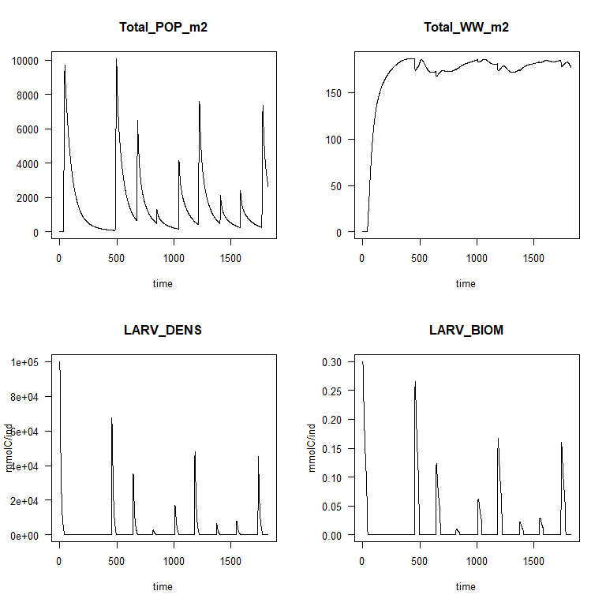

```r
pop <- mussel_run_debcohort(times = 0:(5*365))
plot(pop, which = c("Total_POP_m2","Total_WW_m2","LARV_DENS","LARV_BIOM"))
```

Similar to the individual model, the population trajectory will change in different environment.

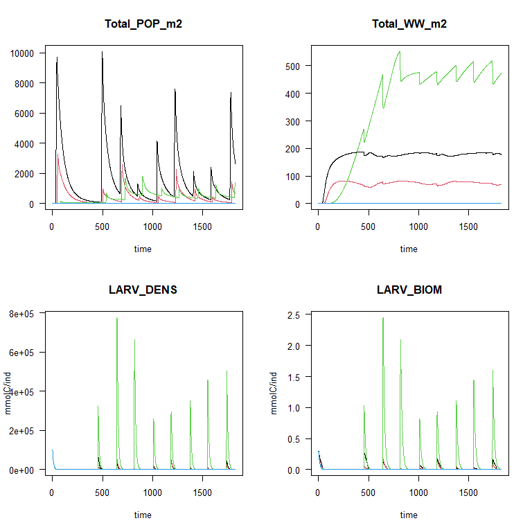

```r
pop_HtHf <- mussel_run_debcohort(times = 0:(5*365), f_Phyto = 10, f_Temp = 20)
pop_HtLf <- mussel_run_debcohort(times = 0:(5*365), f_Phyto = 5, f_Temp = 20)
pop_LtHf <- mussel_run_debcohort(times = 0:(5*365), f_Phyto = 10, f_Temp = 5)
pop_LtLf <- mussel_run_debcohort(times = 0:(5*365), f_Phyto = 5, f_Temp = 5)

plot(pop_HtHf,pop_HtLf,pop_LtHf,pop_LtLf,
     which = c("Total_POP_m2","Total_WW_m2","LARV_DENS","LARV_BIOM"))
```

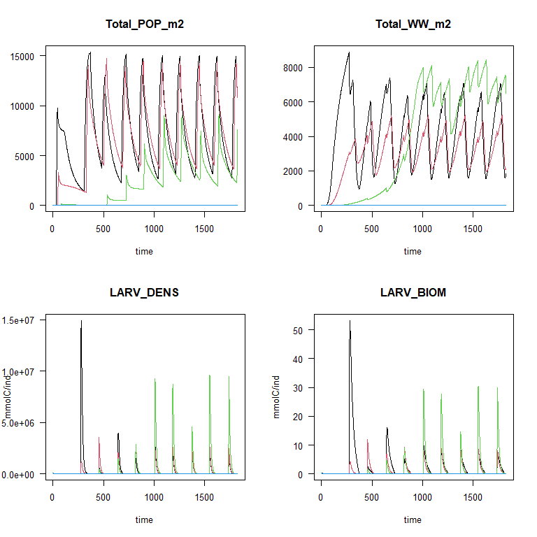

```r
pop_HtHf <- mussel_run_debcohort(times = 0:(5*365), f_Phyto = 10, f_Temp = 20,dynamic_environment = FALSE)
pop_HtLf <- mussel_run_debcohort(times = 0:(5*365), f_Phyto = 5, f_Temp = 20,dynamic_environment = FALSE)
pop_LtHf <- mussel_run_debcohort(times = 0:(5*365), f_Phyto = 10, f_Temp = 5,dynamic_environment = FALSE)
pop_LtLf <- mussel_run_debcohort(times = 0:(5*365), f_Phyto = 5, f_Temp = 5,dynamic_environment = FALSE)

plot(pop_HtHf,pop_HtLf,pop_LtHf,pop_LtLf,
     which = c("Total_POP_m2","Total_WW_m2","LARV_DENS","LARV_BIOM"))
```

## Population in a dynamic environment

To add an additional layer of realism, we can implement our dynamic forcings & dynamic environment into the population model. Under these conditions we need to start the population at time 100, because larva can fail to settle successfully if we start the timeseries in winter (t0 = jan1)

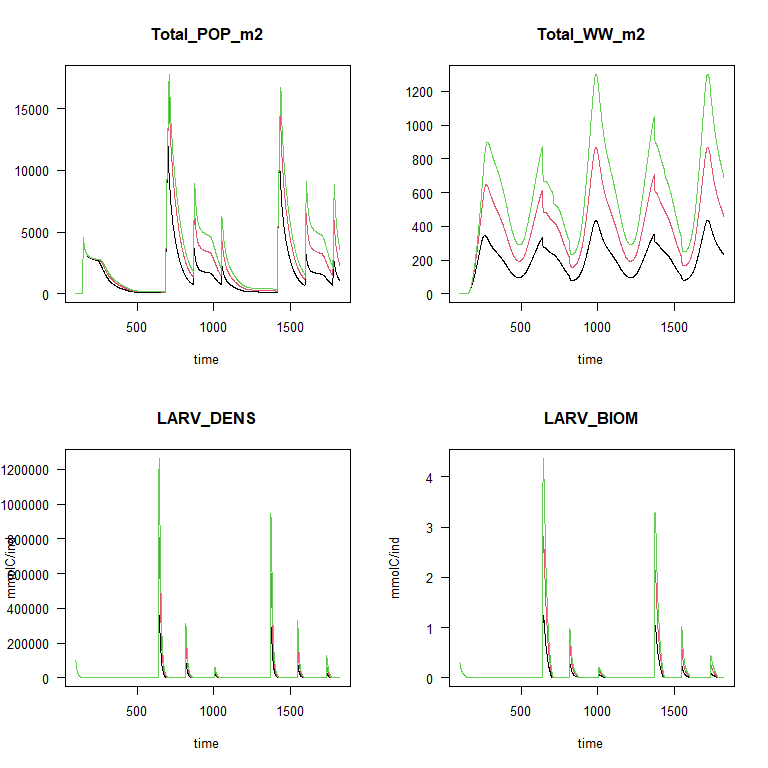

```r
pop_dyna <- mussel_run_debcohort(times = 100:(5*365),parms = c(water_renew = 1),
                                f_Phyto = f_dynaPHYTO,
                                f_Temp = f_dynaTEMP,
                                f_Detritus = f_dynaDT)
pop_dyna2 <- mussel_run_debcohort(times = 100:(5*365),parms = c(water_renew = 2),
                                f_Phyto = f_dynaPHYTO,
                                f_Temp = f_dynaTEMP,
                                f_Detritus = f_dynaDT)
pop_dyna3 <- mussel_run_debcohort(times = 100:(5*365),parms = c(water_renew = 3),
                                f_Phyto = f_dynaPHYTO,
                                f_Temp = f_dynaTEMP,
                                f_Detritus = f_dynaDT)


plot(pop_dyna,pop_dyna2,pop_dyna3,
     which = c("Total_POP_m2","Total_WW_m2","LARV_DENS","LARV_BIOM"))
```